# 5 — Actuation, PD Control, and Rhythm

The motors were never ideal · SOC4180 Robot and AI

Hong Jeong

## A lie we have been telling

Last week we commanded joint angles and the robot went there. Mostly.

Look again at the Week 4 data: the pelvis was commanded to 0.72 m and never quite arrived. Something between “the command” and “the motion” is not ideal, and this week we open it up.

Three questions:

1. What *is* a position actuator, mechanically?
2. Why does the robot sag below its commanded height?
3. What happens when the motors are not strong enough?

The actuator is **declared in the model file** (Layer 2, the robot model), but what it declares is a **controller** (Layer 4). This week sits on that seam.

## Colour code for the week

The same colours mean the same things in every equation and every drawing:

| symbol | meaning | unit | colour |
| --- | --- | --- | --- |
| ${\color{#3b7dd8}{q,\ \dot q,\ \ddot q}}$ | the **joint angle**, its velocity, its acceleration | rad, rad/s, rad/s² | blue |
| ${\color{#e8743b}{q_{\text{ref}}}}$ | the **command** — MuJoCo calls it `ctrl` | rad | orange |
| ${\color{#2a9d5c}{\tau}}$ | a **torque** on the joint | N·m | green |
| ${\color{#c0392b}{k_p}}$ | **stiffness**: torque per radian of error | N·m/rad | red |
| ${\color{#8e44ad}{k_v}}$ | **damping**: torque per rad/s of velocity | N·m·s/rad | purple |
| ${\color{#8c564b}{M}}$ | the **inertia** the joint has to swing | kg·m² | brown |

Two derived numbers appear all week and are named when they arrive: $\omega_n$ (how fast the joint responds) and $\zeta$ (whether it overshoots).

## The actuator is a controller in disguise

MuJoCo’s “position actuator” is not a servo that magically achieves an angle. It is a **PD controller** — proportional plus derivative — written into the model file:

$${\color{#2a9d5c}{\tau}} = {\color{#c0392b}{k_p}}\,({\color{#e8743b}{q_{\text{ref}}}} - {\color{#3b7dd8}{q}}) \;-\; {\color{#8e44ad}{k_v}}\,{\color{#3b7dd8}{\dot{q}}}$$

- ${\color{#e8743b}{q_{\text{ref}}}} - {\color{#3b7dd8}{q}}$ — the **error**: how far the joint is from where it was told to be
- ${\color{#c0392b}{k_p}}\times$ error — the **P** term, a torque that pulls toward the command
- $-{\color{#8e44ad}{k_v}}\,{\color{#3b7dd8}{\dot q}}$ — the **D** term, a torque that opposes motion, whichever way it goes

```
kp : [500.]            (identical on every joint)
kv : 4.55 .. 43.01   (27 distinct values)
```

## Where the gains live in the model

MuJoCo has one general formula for every actuator, and a `<position>` actuator is just one choice of its numbers:

$${\color{#2a9d5c}{\tau}} = \underbrace{g_0}_{\texttt{gainprm[0]}}\,{\color{#e8743b}{\text{ctrl}}}
\;+\; \underbrace{b_0}_{\texttt{biasprm[0]}}
\;+\; \underbrace{b_1}_{\texttt{biasprm[1]}}\,{\color{#3b7dd8}{q}}
\;+\; \underbrace{b_2}_{\texttt{biasprm[2]}}\,{\color{#3b7dd8}{\dot q}}$$

Choose $g_0 = {\color{#c0392b}{k_p}}$, $b_0 = 0$, $b_1 = -{\color{#c0392b}{k_p}}$, $b_2 = -{\color{#8e44ad}{k_v}}$, collect terms, and it is the PD law of the last slide.

```
actuator 3 : left_knee_joint
gainprm[0]      = +500.000     (= +kp)
biasprm[0:3]    = [   0.    -500.     -15.847]   (= 0, -kp, -kv)
```

That is why `soc4180.scale_gains` has to write **three** numbers per actuator: $k_p$ appears twice. Change only the gain and the servo no longer pulls toward `ctrl` — it pulls toward some other angle.

## The servo, drawn: a spring and a damper

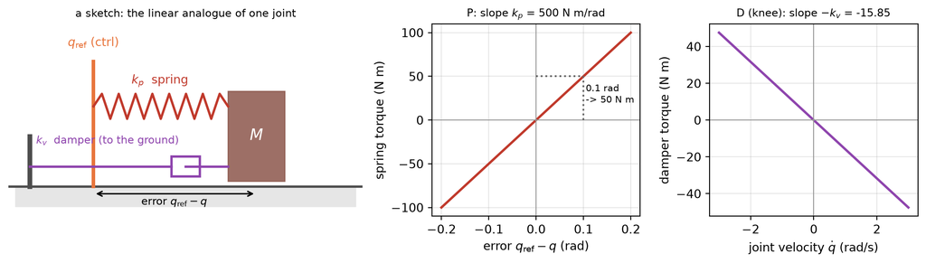

The left picture is a **sketch** (a sliding block standing in for a rotating link: position ↔︎ angle, force ↔︎ torque, mass ↔︎ inertia). The spring is attached to the *command*, so moving `ctrl` drags the spring’s end; the damper is attached to the *ground*, so it brakes any motion, even motion toward the target. The two plots are the real knee’s numbers: every 0.1 rad of error buys 50 N·m, and every 1 rad/s of speed costs 15.85 N·m of brake.

## One joint is a second-order system

Take one joint, gravity off, every other joint held still.

**Step 1 — Newton for rotation.** Inertia × angular acceleration = the torque on the joint:
$${\color{#8c564b}{M}}\,{\color{#3b7dd8}{\ddot q}} = {\color{#2a9d5c}{\tau}}.$$

**Step 2 — the only torque is the servo’s.** Substitute the PD law:
$${\color{#8c564b}{M}}\,{\color{#3b7dd8}{\ddot q}} = {\color{#c0392b}{k_p}}({\color{#e8743b}{q_{\text{ref}}}} - {\color{#3b7dd8}{q}}) - {\color{#8e44ad}{k_v}}\,{\color{#3b7dd8}{\dot q}}.$$

**Step 3 — collect the unknown on the left:**
$${\color{#8c564b}{M}}\,{\color{#3b7dd8}{\ddot q}} + {\color{#8e44ad}{k_v}}\,{\color{#3b7dd8}{\dot q}} + {\color{#c0392b}{k_p}}\,{\color{#3b7dd8}{q}} = {\color{#c0392b}{k_p}}\,{\color{#e8743b}{q_{\text{ref}}}}.$$

This is the **mass–spring–damper equation** — the most-studied equation in engineering. It is *second order* because the highest derivative is $\ddot q$, so we need two starting facts (angle and velocity) to know the future.

- ${\color{#8c564b}{M}}$ — the inertia of **everything beyond the joint** about its axis (the knee swings the shin and foot). MuJoCo computes it as the diagonal entry of the **mass matrix** `mj_fullM`, and adds the motor’s own rotor inertia (`armature`, 0.01 kg·m² on every leg joint of the G1).
- The right-hand side is the **input**; the left-hand side is how the joint **responds**.

## Solving it: the characteristic equation

Command a **step**: ${\color{#e8743b}{q_{\text{ref}}}}$ jumps and then stays fixed. Write the error $e = {\color{#3b7dd8}{q}} - {\color{#e8743b}{q_{\text{ref}}}}$; since ${\color{#e8743b}{q_{\text{ref}}}}$ is constant, $\dot e = {\color{#3b7dd8}{\dot q}}$ and $\ddot e = {\color{#3b7dd8}{\ddot q}}$, and the equation loses its right side:
$${\color{#8c564b}{M}}\,\ddot e + {\color{#8e44ad}{k_v}}\,\dot e + {\color{#c0392b}{k_p}}\,e = 0 .$$

**Step 1 — try $e = e^{rt}$** (the same guess as Week 4’s LIPM). Every term carries $e^{rt}$; cancel it:
$${\color{#8c564b}{M}}\,r^2 + {\color{#8e44ad}{k_v}}\,r + {\color{#c0392b}{k_p}} = 0 .$$

**Step 2 — divide by ${\color{#8c564b}{M}}$ and name the two ratios:**
$$r^2 + 2\zeta\omega_n\,r + \omega_n^2 = 0,
\qquad \omega_n = \sqrt{\frac{{\color{#c0392b}{k_p}}}{{\color{#8c564b}{M}}}},
\qquad \zeta = \frac{{\color{#8e44ad}{k_v}}}{2\sqrt{{\color{#c0392b}{k_p}}\,{\color{#8c564b}{M}}}} .$$
(Check: $\omega_n^2 = {\color{#c0392b}{k_p}}/{\color{#8c564b}{M}}$ and $2\zeta\omega_n = {\color{#8e44ad}{k_v}}/{\color{#8c564b}{M}}$ — exactly the two coefficients.)

## The roots decide everything

**Step 3 — the quadratic formula** on $r^2 + 2\zeta\omega_n\,r + \omega_n^2 = 0$:
$$r = \omega_n\left(-\zeta \pm \sqrt{\zeta^2 - 1}\right).$$

- $\omega_n$ — the **natural frequency** (rad/s): how fast the joint would ring with no damping. Units: $\sqrt{(\text{N·m/rad})/(\text{kg·m}^2)} = 1/\text{s}$.
- $\zeta$ — the **damping ratio** (no unit). The square root decides everything: $\zeta < 1$ makes it imaginary, $\zeta = 1$ makes it zero, $\zeta > 1$ keeps it real.

**Step 4 — the solution is a sum of the two exponentials,** $e(t) = A\,e^{r_1 t} + B\,e^{r_2 t}$ (or $(A + Bt)\,e^{-\omega_n t}$ when the two roots coincide), with $A$ and $B$ fixed by the two starting facts: the step’s size $e(0) = e_0$ (the error just after the jump) and $\dot e(0) = 0$ (the joint was at rest). Both roots have negative real part whenever ${\color{#8e44ad}{k_v}} > 0$, so both terms decay and **the joint always arrives** — the only question is *how*. The next slide writes out $A e^{r_1 t} + B e^{r_2 t}$ for each case.

## Three regimes, three kinds of root

|  | roots $r$ | error $e(t)$, starting at $e_0$ with zero velocity | what you see |
| --- | --- | --- | --- |
| $\zeta < 1$ **under-damped** | complex: $-\zeta\omega_n \pm i\,\omega_d$, $\ \omega_d = \omega_n\sqrt{1-\zeta^2}$ | $e_0\,e^{-\zeta\omega_n t}\left(\cos\omega_d t + \dfrac{\zeta}{\sqrt{1-\zeta^2}}\sin\omega_d t\right)$ | rings: overshoots, swings back, decays |
| $\zeta = 1$ **critical** | one double root $-\omega_n$ | $e_0\,(1 + \omega_n t)\,e^{-\omega_n t}$ | fastest arrival **without** overshoot |
| $\zeta > 1$ **over-damped** | two real: $r_1, r_2 < 0$ | $e_0\,\dfrac{r_2 e^{r_1 t} - r_1 e^{r_2 t}}{r_2 - r_1}$ | creeps in; the slower root $r_1$ dominates |

A complex root $-a \pm i b$ means $e^{-at}$ (decay) times $\cos bt$ (oscillation): that is where ringing comes from. Each formula was fitted to the two starting facts, $e(0) = e_0$ and $\dot e(0) = 0$ — put $t = 0$ in and check.

## How much overshoot?

**Step 1 — find the peak.** For $\zeta < 1$, differentiate the error formula; the cosine and sine terms combine and leave $\dot e(t) = -e_0\,\dfrac{\omega_n}{\sqrt{1-\zeta^2}}\,e^{-\zeta\omega_n t}\sin\omega_d t$. It is zero when $\sin\omega_d t = 0$, first at $t_p = \pi/\omega_d$.

**Step 2 — evaluate the error there.** Put $t_p$ into $e_0\,e^{-\zeta\omega_n t}(\cos\omega_d t + \ldots\sin\omega_d t)$: $\cos\pi = -1$ and $\sin\pi = 0$, so $e(t_p) = -e_0\,e^{-\zeta\omega_n\pi/\omega_d}$. The minus sign says the error has changed side: the joint is *past* the target.

**Step 3 — divide by the step and simplify** $\omega_n/\omega_d = 1/\sqrt{1-\zeta^2}$:

$$\text{overshoot} = \frac{|e(t_p)|}{|e_0|} = e^{-\zeta\omega_n \pi/\omega_d} = \exp\!\left(-\frac{\pi\zeta}{\sqrt{1-\zeta^2}}\right).$$

It depends on $\zeta$ **only**: $\zeta = 0.25$ gives 44 %, $\zeta = 0.5$ gives 16 %, and at $\zeta = 1$ the peak time $t_p = \pi/\omega_d$ becomes infinite — no peak. **Stiffness sets the speed; the damping *ratio* sets the shape.**

## The three regimes, drawn for the knee

The left knee’s numbers, with the damping scaled $\times\frac14$, $\times 1$, $\times 4$ — a 0.5 rad step:

```
knee: M = 0.1256 kg m^2, kp = 500  ->  omega_n = 63.1 rad/s = 10.0 Hz, 1/omega_n = 15.8 ms
  kv x0.25: zeta = 0.25, roots = [-15.8+61.1j -15.8-61.1j], overshoot 44.4%, within 1 % after 0.030 s
  kv x1.0 : zeta = 1.00, roots = [-63.1 -63.1], overshoot  0.0%, within 1 % after 0.105 s
  kv x4.0 : zeta = 4.00, roots = [-496.8   -8. ], overshoot  0.0%, within 1 % after 0.577 s
```

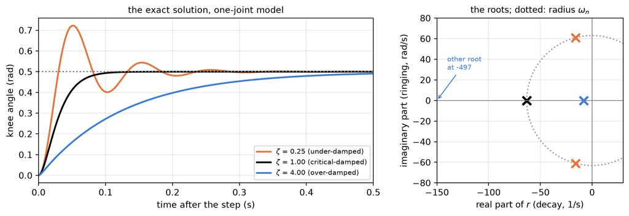

## Reading the numbers

- $\omega_n \approx 63$ rad/s, i.e. **10 Hz**: an undamped knee would ring ten times a second. $1/\omega_n \approx 16$ ms is the joint’s basic time unit.
- **Critical ($\zeta = 1$, black):** both roots sit at $-\omega_n$, on the real axis — no ringing. It arrives within 1 % after 0.105 s. That is $6.64/\omega_n$, because $(1 + x)e^{-x} = 0.01$ at $x = 6.64$: about **seven time units**.
- **Under ($\zeta = 0.25$, orange):** the roots leave the axis, and the imaginary part (61 rad/s) is the ringing. Overshoot $\exp(-\pi\cdot0.25/\sqrt{1-0.0625}) = 44\%$. It gets *near* the target first (0.030 s) and then spends time swinging through it.
- **Over ($\zeta = 4$, blue):** two real roots, $-8$ and $-497$. The fast one dies in milliseconds; the slow one, $e^{-8t}$, is what you wait for: 0.577 s to reach 1 %, five times slower than critical.

**The circle.** A complex pair always has size exactly $\omega_n$: $|r|^2 = (\zeta\omega_n)^2 + \omega_d^2 = \omega_n^2$. So below $\zeta = 1$ the damping slides the pair *around* the circle towards the real axis; at $\zeta = 1$ they meet on it at $-\omega_n$; above, they split along the axis, one inside and one outside, with product $\omega_n^2$ ($8.0 \times 496.8 \approx 63.1^2$). Stiffness sets the circle’s size, damping sets where on it you are.

## What the G1’s designers chose

Read ${\color{#8c564b}{M}}$ off the mass matrix for every actuated joint and compute $\zeta$:

```
  left_hip_pitch_joint       M = 0.9250   kv = 43.01   zeta = 1.00
  left_knee_joint            M = 0.1256   kv = 15.85   zeta = 1.00
  left_ankle_pitch_joint     M = 0.0128   kv =  5.06   zeta = 1.00
  waist_yaw_joint            M = 0.2804   kv = 23.29   zeta = 0.98
  left_shoulder_roll_joint   M = 0.1865   kv = 13.49   zeta = 0.70

all twelve leg joints: zeta = 1.00 .. 1.00
```

**Every leg joint is critically damped, $\zeta = 1.00$.** That is why ${\color{#8e44ad}{k_v}}$ varies by a factor of ten while ${\color{#c0392b}{k_p}}$ does not: solve $\zeta = 1$ for the damping,

$${\color{#8e44ad}{k_v}} = 2\sqrt{{\color{#c0392b}{k_p}}\,{\color{#8c564b}{M}}},$$

and a joint that swings more inertia needs more damping. The heavy hip and the light ankle therefore respond with the *same shape*. The arms are looser, 0.7 to 1.9.

## The step response, measured

Gravity off, the robot lifted 0.5 m so nothing touches the floor, and the left knee is asked to go from 0 to 0.5 rad. Solid: MuJoCo. Dashed: the one-joint formula.

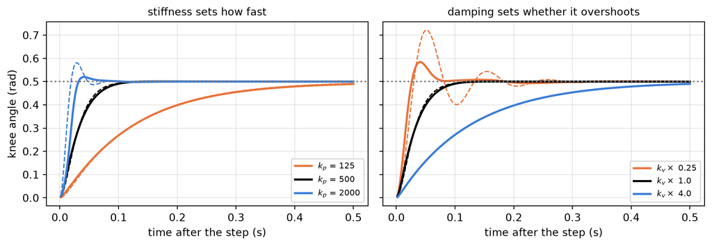

```
           zeta | MuJoCo: 1 % overshoot | formula: 1 % overshoot
kp x0.25   2.00 |     not yet      0.0% |      not yet      0.0%
kp x1.0    1.00 |     0.110 s      0.1% |      0.106 s      0.0%
kp x4.0    0.50 |     0.032 s      4.0% |      0.048 s     16.2%
kv x0.25   0.25 |     0.026 s     16.9% |      0.030 s     44.4%
kv x1.0    1.00 |     0.110 s      0.1% |      0.106 s      0.0%
kv x4.0    4.00 |     not yet      0.0% |      not yet      0.0%
```

## Reading the step response

- **Stiffness ×4** reaches 1 % in 0.032 s against 0.110 s — about 3.4 times sooner. Two things add up: $\omega_n \propto \sqrt{k_p}$ doubles, and $\zeta \propto 1/\sqrt{k_p}$ halves to 0.5, which rushes in and pays with a 4.0 % overshoot. It also **draws four times the torque**: at the first instant the error is the whole 0.5 rad, so ${\color{#2a9d5c}{\tau}} = {\color{#c0392b}{k_p}} \times 0.5$ — 250 N·m nominal, 1000 N·m at ×4.
- **A quarter of the stiffness, or four times the damping**, never gets within 1 % in half a second (“not yet” in the table): over-damped, $\zeta = 2$ and $4$.
- **The nominal pair** is within 1 % at 0.110 s with no overshoot — the formula says 0.106 s (sampled every 2 ms, as MuJoCo is). $\zeta = 1$ predicted it.

But the under-damped cases **overshoot less than the formula says**: 16.9 % measured against 44.4 % for ${\color{#8e44ad}{k_v}}/4$. The next slide says why.

(The lab’s `servo.py` prints smaller overshoots — 4.6 % for ${\color{#8e44ad}{k_v}}/4$ — because it starts with the feet on the floor and a foot touches it during the step. This slide lifts the robot clear. Same law, different load.)

## Why the formula over-predicts the ringing

The one-joint model assumed “every other joint held still”. The knee in a floating robot does not push against a wall — it pushes against the rest of the body, which moves back. Two limits bracket the truth:

```
every other joint locked   M_ii        = 0.1256 kg m^2 -> zeta(kv/4) = 0.25, overshoot 44.4%
every other joint free     1/(M^-1)_ii = 0.0412 kg m^2 -> zeta(kv/4) = 0.44, overshoot 21.8%
```

- ${\color{#8c564b}{M_{ii}}}$ (the diagonal) is the inertia when everything else is welded in place.
- $1/(M^{-1})_{ii}$ is the inertia when everything else — the other joints and the floating pelvis — is **perfectly free** to move out of the way. Less to push, so a smaller number and more damping per unit inertia.
- The real robot is in between: the other 28 joints are servoed, stiff but not rigid, and the pelvis floats. The measured 16.9 % is closer to the “free” limit, and even a little below it: a one-joint model, with either inertia, brackets the robot rather than fitting it.

**The formula is right about the direction and about the design rule** ($\zeta = 1$ gives no overshoot), and only approximate about the numbers. Use it to choose gains; measure to know what you got.

## Verify it, do not believe it

If the PD law really is the actuator, we can predict the torque exactly:

```
predicted torque = -150.000 N m
actual   torque  = -150.000 N m
```

Read it: error $0 - 0.30 = -0.30$ rad, times 500 N·m/rad, is $-150$ N·m — a torque pulling the knee back toward straight. A spring, pulling the joint back toward its setpoint with a force proportional to the error. **That is why the robot sags: a spring at rest is a spring under load, and load means deflection.**

## Sag under gravity, derived

Turn gravity back on. Gravity pulls on everything beyond the joint and adds a torque ${\color{#2a9d5c}{\tau_g}}$ (MuJoCo’s `qfrc_bias` with the sign flipped, when the robot is at rest):

**Step 1 — Newton with gravity:**
$${\color{#8c564b}{M}}\,{\color{#3b7dd8}{\ddot q}} = {\color{#c0392b}{k_p}}({\color{#e8743b}{q_{\text{ref}}}} - {\color{#3b7dd8}{q}}) - {\color{#8e44ad}{k_v}}\,{\color{#3b7dd8}{\dot q}} + {\color{#2a9d5c}{\tau_g}}.$$

**Step 2 — wait until it stops.** At rest ${\color{#3b7dd8}{\ddot q}} = {\color{#3b7dd8}{\dot q}} = 0$, so the damper does nothing and the spring alone holds the load:
$$0 = {\color{#c0392b}{k_p}}({\color{#e8743b}{q_{\text{ref}}}} - {\color{#3b7dd8}{q}}) + {\color{#2a9d5c}{\tau_g}} .$$

**Step 3 — solve for the angle:**
$$\boxed{\ {\color{#3b7dd8}{q}} - {\color{#e8743b}{q_{\text{ref}}}} = \frac{{\color{#2a9d5c}{\tau_g}}}{{\color{#c0392b}{k_p}}}\ }$$

## Reading the sag formula

$${\color{#3b7dd8}{q}} - {\color{#e8743b}{q_{\text{ref}}}} = \frac{{\color{#2a9d5c}{\tau_g}}}{{\color{#c0392b}{k_p}}}$$

- The joint comes to rest **past** its command, in the direction gravity pulls, by load ÷ stiffness.
- Double ${\color{#c0392b}{k_p}}$, halve the sag. It is **never zero** for a finite spring: the error *is* what makes the holding torque.
- A PID controller would remove it with an integral (I) term that keeps growing while any error remains. MuJoCo’s position actuator has no I term — the formula in *Where the gains live* has nothing that remembers the past.
- The G1’s joints also have `frictionloss` 0.3 N·m, a small dead band: the spring may rest up to $0.3/{\color{#c0392b}{k_p}}$ either side of the prediction.

## P, PD, PI, PID: what each term buys

Our servo is $\tau = {\color{#c0392b}{k_p}}\,e - {\color{#8e44ad}{k_v}}\,\dot q$ with $e = q_{\text{ref}} - q$: a **PD** controller. Two more terms complete the family:

$$\tau = \underbrace{{\color{#c0392b}{k_p}}\,e}_{\text{P: now}} + \underbrace{{\color{#2a9d5c}{k_i}}\!\int e\,dt}_{\text{I: the past}} + \underbrace{{\color{#8e44ad}{k_d}}\,\dot e}_{\text{D: the trend}}$$

- **P** reacts to the error now. **I** adds up the error over time, so it keeps growing until the error is zero. **D** reacts to how fast the error is changing, so it brakes before the target. (For a constant command $\dot e = -\dot q$, which is our $-k_v\dot q$.)

The textbook comparison (a rule of thumb, not a measurement; the measured version is on the next slide):

| Controller | Rise time | Overshoot | Steady-state error |
| --- | --- | --- | --- |
| P | medium | often | usually non-zero |
| PD | fast | small | may remain |
| PI | medium | moderate | zero |
| PID | fast | small | zero |

The next two slides test this table on the knee, with a constant gravity load.

## P, PD, PI, PID on one joint, measured

The knee’s inertia $M$ and ${\color{#c0392b}{k_p}} = 500$, a 0.5 rad step, and a constant 10 N·m gravity load pulling back. The joint also has a little natural damping ($\zeta_{\text{joint}} = 0.15$), so “P” is not frictionless. Gains: P $= (k_p)$; PD adds ${\color{#8e44ad}{k_v}}$ for $\zeta = 1$; PI adds ${\color{#2a9d5c}{k_i}} = 300$; PID has both.

```
load/kp = 20 mrad sag expected without an I term
      rise 10-90%  overshoot  final error  within 2% after
P           19 ms      55.6%     20.00 mrad         4.00 s
PD          78 ms       0.0%     20.00 mrad         4.00 s
PI          19 ms      57.0%      1.69 mrad         1.04 s
PID         72 ms       0.0%      0.80 mrad         0.17 s
```

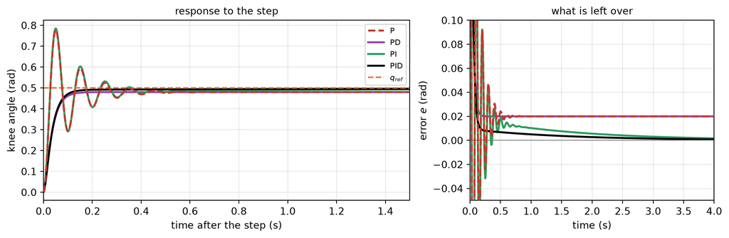

## Reading the comparison

- **P and PD keep the sag.** The error settles at load $/k_p$ = 20 mrad: a spring needs an error to push. The D term changes *how* it arrives, not *where*.
- **The I term is the only one that removes it**, by integrating the leftover error until the extra torque equals the load. PI and PID head for zero: after 4 s the error is 1.7 mrad (PI) and 0.8 mrad (PID), still shrinking, against 20 for P and PD.
- **D is the brake.** With D the overshoot disappears (0.0 %, against 56 % for P); without it the lightly damped joint rings. PD’s rise time is *longer* than P’s here: P is quick because it is under-damped, and the quickness is the ringing.
- **I costs speed and invites ringing**: PI overshoots as much as P (57 %) and needs 1.0 s to come within 2 %, because the integral keeps pushing after the error crosses zero. PID tames that with D: 0.0 % overshoot, inside 2 % after 0.17 s. P and PD never get inside 2 %, since their 20 mrad sag is 4 % of the step.

This matches the table in direction, and the measured numbers above are the real ones for this joint. The G1’s servo is **PD**: it sags (week 5, next), and MuJoCo has no integral term.

## The three terms, drawn as signals

For the PID run, the torque each term contributes over time — the sum is what the motor delivers:

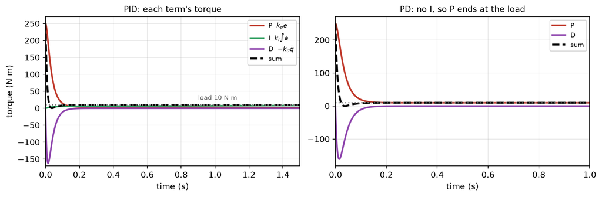

```
PID at 4 s: P +0.40, I +9.61, D -0.01 N m (sum +10.00 = load 10)
```

At 4 s the P term is down to 0.4 N·m (almost no error) and the **I term carries 9.6 N·m of the load**: it has *remembered* the sag. PD has no memory, so its P term must stay at 10 N·m, which means an error of 20 mrad for ever.

## Sag, measured on one joint

The robot stands; its left arm is held straight out in front (shoulder pitch $-1.57$ rad, elbow 0). Only the shoulder’s stiffness is changed:

```
    kp  tau_g (N m)  predicted tau_g/kp  measured q - q_ref  wrist drop
   125        4.785           38.28 mrad           38.23 mrad     14.6 mm
   250        4.750           19.00 mrad           18.97 mrad      7.2 mm
   500        4.732            9.46 mrad            9.45 mrad      3.6 mm
  1000        4.723            4.72 mrad            4.72 mrad      1.8 mm
  2000        4.718            2.36 mrad            2.36 mrad      0.9 mm
```

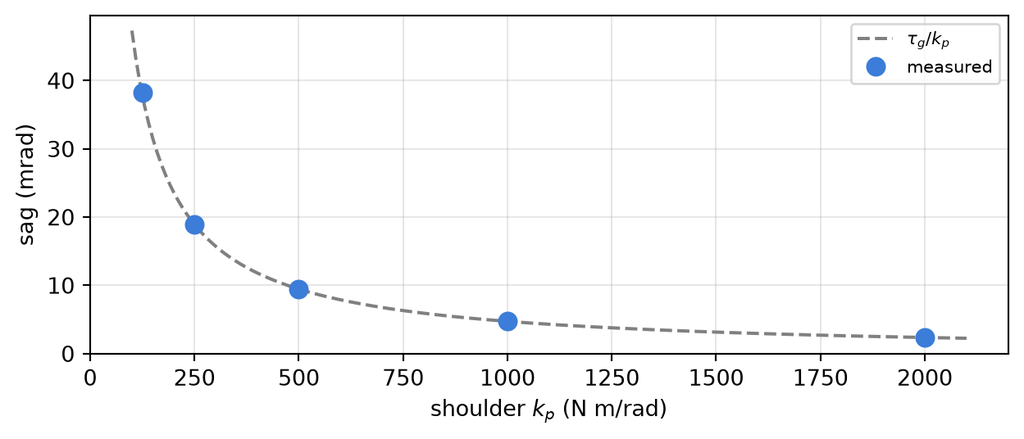

The arm (0.38 m from shoulder to wrist) pulls with 4.7 N·m. At the shipped ${\color{#c0392b}{k_p}} = 500$ it sags 9.5 mrad — half a degree, 3.6 mm at the wrist — and every point lands on $\tau_g/k_p$ to within 0.05 mrad.

## Measure the sag

The same law, for a whole walking robot:

```
commanded pelvis height : 0.720 m
mean sag                : +11.0 mm
worst sag               : +27.1 mm
peak joint torque       : 123.7 N m
```

Eleven millimetres of steady droop. Not a bug — the necessary deflection of finite springs holding up a 33 kg robot. Each leg joint sags by its own $\tau_g/k_p$, and the pelvis drop is those small angles added up along the leg.

## Sag against stiffness

The derivation says sag $\propto 1/k_p$. Sweep the stiffness of **every** joint and check:

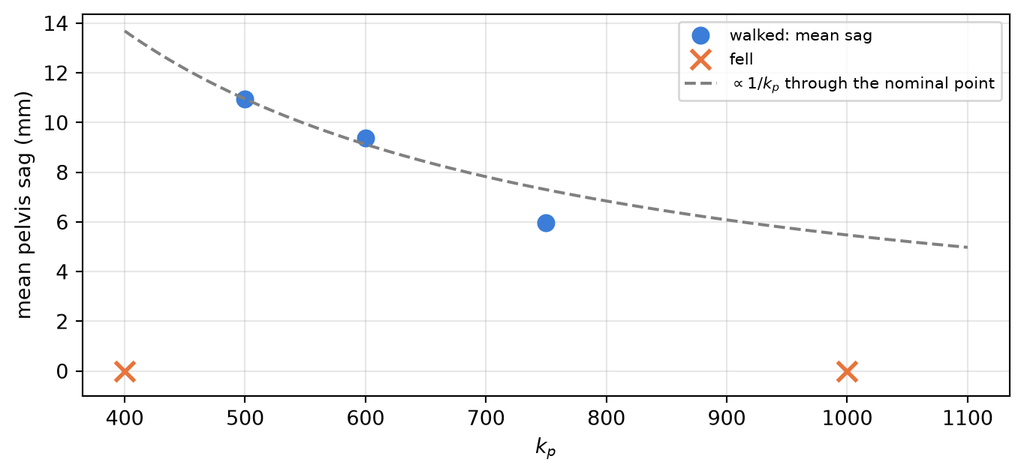

```
kp 400: fell  kp 500: 11.0 mm  kp 600: 9.4 mm  kp 750: 6.0 mm  kp 1000: fell
```

500 and 600 sit on the $1/k_p$ curve; 750 sags a little less than it predicts (6.0 mm against 7.3) — the pelvis sag is many joints at once, each at its own load, so the single-spring law is a guide, not a fit. Below 500 the robot does not sag more — it **falls**: a leg that gives too much at support exchange has stopped supporting. Above 750 it falls too, for the reason on the next slides — the gait’s timing was tuned against one particular stiffness.

## The motors in this model are infinitely strong

Before tuning anything, check what the simulator is actually giving us:

```
torque limit in the model : None
control limits set?       : True
```

**`None`.** The MJCF constrains the *commanded angle* to the joint range, but places no bound whatsoever on the torque used to get there. Our walker happily drew 124 N·m peaks and nothing objected.

No real motor behaves like this. Every hardware actuator has a stall torque, a thermal limit, and a gearbox that fails. **This is a sim-to-real gap sitting in plain sight in the model file**, and unlike most of them it costs one line to close.

## Saturation, written as maths

A torque limit ${\color{#2a9d5c}{\tau_{\max}}}$ clips the PD law:

$${\color{#2a9d5c}{\tau}} = \operatorname{clip}\!\Big({\color{#c0392b}{k_p}}({\color{#e8743b}{q_{\text{ref}}}} - {\color{#3b7dd8}{q}}) - {\color{#8e44ad}{k_v}}\,{\color{#3b7dd8}{\dot q}},\; -{\color{#2a9d5c}{\tau_{\max}}},\; +{\color{#2a9d5c}{\tau_{\max}}}\Big)$$

($\operatorname{clip}(x, lo, hi)$ returns $x$ if it is between the bounds, otherwise the bound it crossed.)

**Step 1 — where the spring is still a spring.** At rest, the law is linear only while $|{\color{#c0392b}{k_p}}\,e| \le {\color{#2a9d5c}{\tau_{\max}}}$, i.e.
$$|e| \le \frac{{\color{#2a9d5c}{\tau_{\max}}}}{{\color{#c0392b}{k_p}}} = \frac{50}{500} = 0.1\ \text{rad} \approx 5.7° \quad\text{(for a 50 N·m limit)}.$$

**Step 2 — outside that band the stiffness is zero.** The torque is stuck at ${\color{#2a9d5c}{\tau_{\max}}}$: more error buys no more torque, so nothing pulls harder as the joint falls further. Everything derived so far ($\omega_n$, $\zeta$, the sag) assumed the linear band.

**Step 3 — holding a load.** The sag formula needs $|{\color{#2a9d5c}{\tau_g}}| \le {\color{#2a9d5c}{\tau_{\max}}}$. If gravity asks for more, **no value of ${\color{#c0392b}{k_p}}$ helps**: the joint gives way until gravity’s own torque has fallen to ${\color{#2a9d5c}{\tau_{\max}}}$ — for an arm, until it hangs low enough that its lever arm is shorter.

## A weak shoulder, measured

The straight-out arm again, with a torque limit on the shoulder motor alone. Green: gravity’s torque at each angle (`mj_forward`, no simulation).

```
gravity's largest pull on the straight arm: 5.09 N m;  joint friction 0.3 N m
  limit 6 N m: stronger than gravity everywhere -> holds; measured  -89.4 deg
  limit 4 N m: predicted rest between  -33.1 and  -22.2 deg, measured  -32.1 deg
  limit 3 N m: predicted rest between  -16.1 and   -7.6 deg, measured  -12.7 deg
  limit 2 N m: predicted rest between   -2.4 and    4.9 deg, measured   -2.8 deg
```

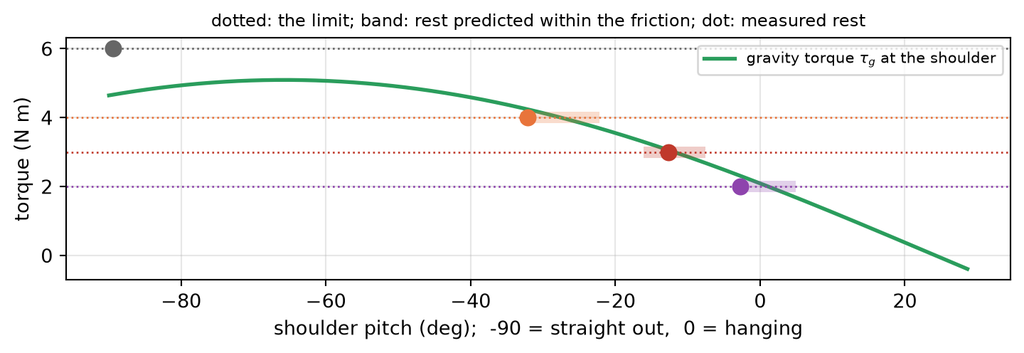

6 N·m beats gravity’s largest pull (5.09): the arm holds. Weaker, it gives way and stops where $\tau_g$ has fallen to the limit — a band, not a point, because the 0.3 N·m joint friction holds either way. 4 and 3 N·m land in their bands; 2 N·m stops 0.4° short. **Stiffness never entered**: past saturation, only ${\color{#2a9d5c}{\tau_{\max}}}$ matters.

## Close it and find the breaking point

```
   30 N m   -> travelled -0.405 m, pelvis 0.061 m   FELL
   45 N m   -> travelled -0.440 m, pelvis 0.061 m   FELL
   50 N m   -> travelled -0.500 m, pelvis 0.061 m   FELL
   55 N m   -> travelled +0.650 m, pelvis 0.718 m   walked
   80 N m   -> travelled +0.660 m, pelvis 0.716 m   walked
  no limit  -> travelled +0.659 m, pelvis 0.716 m   walked
```

A crisp threshold: the gait **needs more than 50 N·m** and survives at 55. Below that the stance leg cannot hold the robot up during weight transfer, and it goes down.

## Where the torque goes

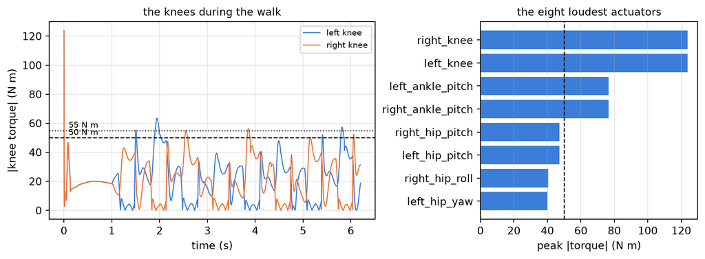

```
left knee above 50 N m for 4.0% of the walk
```

The knee holds the body up in single support and spikes at every support exchange. (The 124 N·m spike at $t \approx 0$ is the robot landing from its starting pose, before walking begins.) It exceeds 50 N·m for about **4% of the walk** — and that is enough. In those moments the knee is outside its linear band (Step 2 of the saturation slide): it stops being a spring, extra bending meets no extra torque, and a limit that bites for a few hundredths of a second drops the robot.

## Tuning the gains

${\color{#c0392b}{k_p}}$ too low and the robot sinks. Too high and it fights itself. Find the window:

```
  kp =    125 -> travelled -0.781 m, pelvis 0.061 m   FELL
  kp =    250 -> travelled -0.729 m, pelvis 0.061 m   FELL
  kp =    500 -> travelled +0.659 m, pelvis 0.716 m   walked
  kp =   1000 -> travelled -0.545 m, pelvis 0.133 m   FELL
  kp =   2000 -> travelled +0.634 m, pelvis 0.134 m   FELL
```

**Only the nominal gain walks.** Halve it and the legs collapse under the robot’s weight; double it and the servos overpower the gait’s timing and throw it over.

## The textbook fix that does not work

The derivation says the *shape* of the response depends only on $\zeta = {\color{#8e44ad}{k_v}} / (2\sqrt{{\color{#c0392b}{k_p}}\,{\color{#8c564b}{M}}})$. So scale ${\color{#8e44ad}{k_v}}$ by $\sqrt{s}$ whenever ${\color{#c0392b}{k_p}}$ is scaled by $s$, and $\zeta$ stays exactly 1.00 on every leg joint. Try it:

```
  kp =    125, kv x0.50 -> pelvis 0.061 m   FELL
  kp =    250, kv x0.71 -> pelvis 0.061 m   FELL
  kp =    500, kv x1.00 -> pelvis 0.716 m   walked
  kp =   1000, kv x1.41 -> pelvis 0.068 m   FELL
  kp =   2000, kv x2.00 -> pelvis 0.136 m   FELL
```

**Still only the nominal gain survives.** The theory is not wrong — it is about a single joint tracking a setpoint. Holding $\zeta$ keeps the *shape* but changes the *speed* ($\omega_n \propto \sqrt{k_p}$) and the *sag* ($\propto 1/k_p$). Our failure is not one joint ringing; it is a *whole-body gait whose timing was tuned against this particular plant*. Change the plant and the trajectory no longer fits it.

Remember that when a learned policy shrugs this off in Week 11.

## Rhythm without a model

The Week 4 walker needed a balance model. Biology often seems not to: a **central pattern generator** (CPG) — a circuit of neurons in the spinal cord — produces rhythmic stepping with no plan at all. Two anti-phase oscillators, driving hips and knees:

```
after 8 s: x=+0.150 m, pelvis 0.129 m
```

## A CPG is coupled oscillators

Give each leg a **phase** ${\color{#3b7dd8}{\phi}}$ (blue here: the state; ${\color{#8e44ad}{w}}$ purple: the coupling) (radians, going round and round: $\phi$ and $\phi + 2\pi$ are the same moment of the stride). Each phase advances at its own rate and is **nudged** by the other:

$${\color{#3b7dd8}{\dot\phi_L}} = \omega_L + {\color{#8e44ad}{w}}\sin({\color{#3b7dd8}{\phi_R}} - {\color{#3b7dd8}{\phi_L}} - \pi),
\qquad
{\color{#3b7dd8}{\dot\phi_R}} = \omega_R + {\color{#8e44ad}{w}}\sin({\color{#3b7dd8}{\phi_L}} - {\color{#3b7dd8}{\phi_R}} + \pi)$$

- $\omega_L, \omega_R$ — each leg’s own stepping rate, $2\pi f$ (rad/s); $f$ = stride cycles per second
- ${\color{#8e44ad}{w}}$ — the **coupling** strength (1/s): how hard each leg pulls the other’s phase
- $\pi$ — the **desired phase offset**: the legs half a stride apart, i.e. alternating

**Step 1 — watch the phase error** $e = {\color{#3b7dd8}{\phi_R}} - {\color{#3b7dd8}{\phi_L}} - \pi$. Subtract the two equations (note $\phi_L - \phi_R + \pi = -e$):
$$\dot e = (\omega_R - \omega_L) - 2{\color{#8e44ad}{w}}\sin e .$$

One equation in one unknown: the whole two-leg question is now “where does $e$ go?”

## Why the legs lock

$$\dot e = (\omega_R - \omega_L) - 2{\color{#8e44ad}{w}}\sin e, \qquad e = {\color{#3b7dd8}{\phi_R}} - {\color{#3b7dd8}{\phi_L}} - \pi$$

**Step 2 — equal rates.** $\dot e = -2{\color{#8e44ad}{w}}\sin e$. Near $e = 0$, $\sin e \approx e$, so $e(t) = e_0\,e^{-2wt}$ — the same kind of decaying exponential as the servo. The legs **lock into anti-phase**, the error shrinking by a factor $\mathrm{e} \approx 2.72$ every $1/(2w)$ seconds. $e = \pi$ (both legs together — a hop) is also a rest point, but an unstable one: there $\sin e \approx -(e - \pi)$ pushes away.

**Step 3 — unequal rates**, $\Delta\omega = \omega_R - \omega_L$. The error stops where $\dot e = 0$: $\sin e^* = \Delta\omega / 2w$. That has a solution **only if $|\Delta\omega| \le 2w$** — coupling strong enough to overrule the mismatch locks the legs with a small lag $e^*$; weaker coupling lets them drift apart for ever.

## Coupled oscillators, drawn

```
w =  2.0: 2w = 4.00 vs mismatch 0.628 rad/s -> predicted lag 0.158 rad, measured e after 12 s = +0.158 rad
w = 0.25: 2w = 0.50 vs mismatch 0.628 rad/s -> predicted lag nan rad, measured e after 12 s = +2.609 rad
```

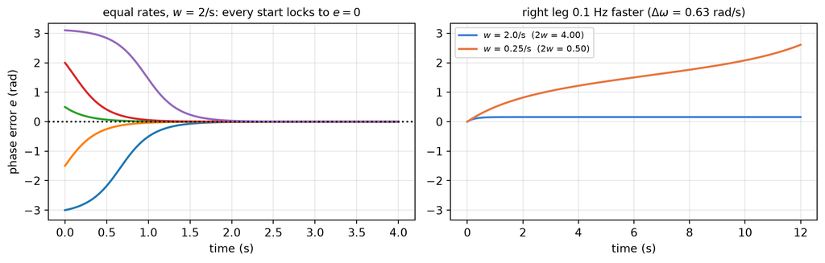

```
equal rates, w = 2: e went 0.500 -> 0.186 rad after 1/(2w) = 0.25 s (the formula says 0.184)
```

Left: whatever the starting error, the legs settle half a stride apart within about a second — the start near $e = \pi$ (a hop) lingers longest before tipping off the unstable point. Right: with strong coupling (blue) the faster leg is held back and the pair locks with a small constant lag; with weak coupling (orange) the error wraps round and round: the legs drift in and out of step.

## What the oscillator commands

The package’s `soc4180.CPG` uses the **locked solution directly**: equal rates, $e = 0$ from the start, so ${\color{#3b7dd8}{\phi_L}} = 2\pi f t$ and ${\color{#3b7dd8}{\phi_R}} = {\color{#3b7dd8}{\phi_L}} + \pi$ with no coupling term to compute — nothing ever disturbs an open-loop clock. Each phase is turned into joint targets (added to the Week 4 crouch):

$$\theta_{\text{hip}} = A_h \sin{\color{#3b7dd8}{\phi}},\qquad
\theta_{\text{knee}} = A_k \max(0, \sin{\color{#3b7dd8}{\phi}}),\qquad
\theta_{\text{ankle}} = -\tfrac{1}{2} A_h \sin{\color{#3b7dd8}{\phi}}$$

- $A_h$ (`hip_amplitude`, 0.25 rad) swings the thigh forward and back
- $A_k$ (`knee_amplitude`, 0.40 rad) bends the knee only on the forward half: $\max(0, \cdot)$ cuts off the negative half, since a knee cannot bend backward
- the ankle counter-rotates by half the hip swing to keep the foot roughly level

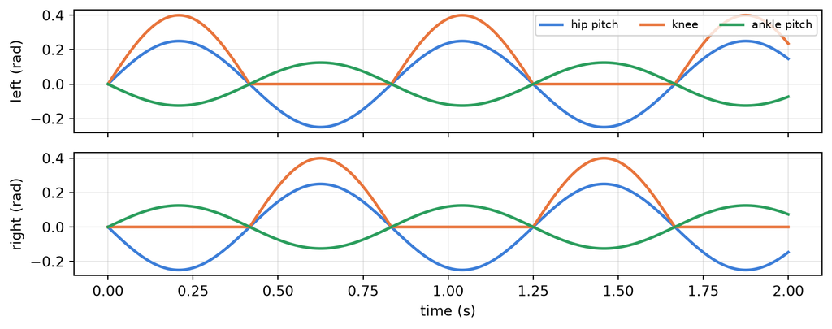

A perfectly plausible stepping pattern. It also has no idea where the floor is.

## Rhythm is not balance

Three stepping rates × three amplitude pairs, 8 s each:

```
0.8 Hz   A=(0.15,0.25): fell at 2.0 s   A=(0.25,0.40): fell at 3.2 s   A=(0.35,0.55): fell at 1.9 s
1.2 Hz   A=(0.15,0.25): fell at 2.2 s   A=(0.25,0.40): fell at 2.2 s   A=(0.35,0.55): fell at 2.0 s
1.6 Hz   A=(0.15,0.25): fell at 2.8 s   A=(0.25,0.40): fell at 2.0 s   A=(0.35,0.55): fell at 2.0 s
```

**All nine fall, between 1.9 and 3.2 seconds in.** The legs move in a perfectly good walking pattern. Nothing keeps the centre of mass over the support polygon, so the robot walks its legs and falls anyway.

**This is the value of Week 4 stated negatively.** The LIPM was not decoration; it was the entire reason the robot stayed up.

## What biology actually does

Real CPGs are not open loop. In an animal the rhythm is continuously **entrained by sensory feedback** — load on the leg, joint angle, skin contact — through reflex pathways that adjust the pattern step by step. In the phase equations that is one more term: $\dot\phi = \omega + (\text{coupling}) + (\text{feedback})$, and a feedback term that speeds up or holds back one leg’s phase is exactly the kind of disturbance Step 3 says the coupling can absorb.

An open-loop oscillator is a CPG with its spinal cord cut off from its body.

That is precisely what we are missing, and it names the next two weeks:

- **Week 6** — read the sensors: what can the robot actually know about itself?
- **Weeks 8+** — let a policy learn the feedback rule instead of deriving it

## Where this leaves us

[output not shown]

Both are **open loop**. Neither reads a single sensor. One works because a human did the balance reasoning in advance; the other does not work at all.

Every remaining week of the course is about closing that loop.

## Lab class: on your laptop

```bash
uv run weeks/05-actuation/lab_servo.py
```

The walker live, a sphere on every leg joint turning green → red with its torque; `1`–`6` pick a `SERVOS` entry. **The code is complete**: `torque_from_pd` is the law, explained; `ENTER` reports its gap from `actuator_force`. **`H` hands the servos over** to it, at 1 kHz (an explicit spring this stiff is unstable at 500 Hz). Break the law and the robot is the week 0 rag doll.

| Step | Do | Right looks like |
| --- | --- | --- |
| 1 | `ENTER` | gap ~1e-12; the two terms explained |
| 2 | `H`, then delete the damping term and `R` `H` | identical walk, then ringing |
| 3 | `2` (50 N·m) then `3` (55 N·m) | knees red at support exchange; 50 falls, 55 walks |
| 4 | `4` and `5` (half and double $k_p$) | half sinks and falls; double is thrown at 5 s |
| 5 | `SERVO_HZ = 500`, `H` | it blows up; explained with week 1 |
| 6 | the lowest $k_p$ that walks eight steps | `ENTER` prints its sag (11 mm at 500) |

## Lab class: `servo.py`, one servo measured

```bash
uv run weeks/05-actuation/servo.py --kp-scale 4          # left knee, 0.5 rad step, gravity off
uv run weeks/05-actuation/servo.py --walk --limit 50
```

Holds `stand`, jumps one joint’s target, prints the law by hand against `actuator_force`, ζ, the time to 1 %, the overshoot, the peak torque; then replays. `--walk` runs the gait under the new gains instead.

| gains | ζ | 1 % reached | overshoot | peak torque |
| --- | --- | --- | --- | --- |
| as shipped | 1.00 | 0.132 s | 0.1 % | 250 N·m |
| kp × 4 | 0.50 | 0.036 s | 2.1 % | 1000 N·m |
| kv / 4 | 0.25 | 0.034 s | 4.6 % | 250 N·m |

| Step | Does | Calls |
| --- | --- | --- |
| 1 | scale gains, set the limit | `scale_gains`, `set_torque_limit` |
| 2 | ζ = kv / 2√(kp M) | `mj_fullM`, `jnt_dofadr[actuator_trnid]` |
| 3 | the step or the walk | `ctrl`, `mj_step`, `actuator_force`, `targets_at` |
| 6 | replay | `launch_viewer(passive=True)` |

## Exercises

1. **Bisect the torque limit.** Narrow the walking threshold between 50 and 55 N·m to 1 N·m. Which joint saturates first, and during which gait phase?
2. **Sag versus stiffness.** Plot mean sag against $k_p$ over the range that does not fall. Is the relationship $1/k_p$ as a linear spring predicts?
3. **Compensate it.** The sag is ~11 mm and roughly constant. Raise the commanded pelvis height by that amount and re-measure. Does the tracking error vanish, and does anything else get worse?
4. **Damping alone.** Hold $k_p$ fixed and sweep $k_v$ over 0.25×–4×. Which failure looks like ringing and which like sluggishness?
5. **Give the CPG a reflex.** Increase knee amplitude on whichever leg carries more load (read `data.actuator_force`). Does one feedback term save it?
6. **Cost of transport.** Compute $\int |\tau \dot q|\,dt$ per metre for the Week 4 walker. Keep the number — you will compare a learned policy against it.
7. **Overshoot from the formula.** Using the knee’s $M_{ii}$ and the free-body $1/(M^{-1})_{ii}$, predict the overshoot for $k_v \times 0.5$, then measure it with the lifted step response. Which limit is closer?
8. **Lock the legs.** In `phase_error`, find the weakest coupling $w$ that still locks a 0.2 Hz mismatch, from Step 3, and check it by simulation.

## Next week

**06 — sensing and state estimation.** The robot has two IMUs and has not used them once. We read gyroscopes and accelerometers, estimate torso orientation from noisy signals, and build the observation vector a learned policy will eventually consume.